# Machine Learning on Barbell Lifting

Xiuren Yap

23 September 2015

```r
library(caret)
library(randomForest)
library(rpart)
library(rpart.plot)
```

Firstly, getting data from the source and reading them.

```r
if(!file.exists("pml-training.csv")){
    download.file("https://d396qusza40orc.cloudfront.net/predmachlearn/pml-training.csv", destfile = "pml-training.csv")
}

if(!file.exists("pml-testing.csv")){
    download.file("https://d396qusza40orc.cloudfront.net/predmachlearn/pml-testing.csv", destfile = "pml-testing.csv")
}

training <- read.csv(file = "pml-training.csv")
testing <- read.csv(file = "pml-testing.csv")
```

Next, both training and testing data has to be cleaned, since there are many NA values and they will affect the process.

```r
#firstly, extract classe data so that it will not be lost
classe <- training$classe

#non-numerical values, user, time data will be removed, as they are not
#used to predict classe. Na values are also removed.

training <- subset(training, select = -c(1:7))
training <- training[, colSums(is.na(training)) == 0]
testing <- subset(testing, select = -c(1:7))
testing <- testing[, colSums(is.na(testing)) == 0]

#Finally, make sure all values in the data are numeric, and insert
#back the classe

training <- training[, sapply(training, is.numeric)]
training$classe <- classe

testing <- testing[, sapply(testing, is.numeric)]
```

Now that the data are cleaned, I will further break the training set into subtraining and subtesting sets, so as to perform a validation before performing the prediction on the test set of 20 observations.

```r
inTrain = createDataPartition(training$classe, p = 0.7, list = FALSE)
subtraining <- training[inTrain, ]
subtesting <- training[-inTrain, ]
```

The subtraining set will now be used to do model fitting, while the subtesting set will be used for validation of the model fit later.

```r
modFit <- train(classe ~ ., data = subtraining, method = "rf", prox = TRUE, ntree = 250)
modFit
```

```
## Random Forest
##
## 13737 samples
##    52 predictor
##     5 classes: 'A', 'B', 'C', 'D', 'E'
##
## No pre-processing
## Resampling: Bootstrapped (25 reps)
## Summary of sample sizes: 13737, 13737, 13737, 13737, 13737, 13737, ...
## Resampling results across tuning parameters:
##
##   mtry  Accuracy   Kappa      Accuracy SD  Kappa SD
##    2    0.9866611  0.9831178  0.002056679  0.002602307
##   27    0.9875308  0.9842193  0.001816974  0.002297739
##   52    0.9820784  0.9773198  0.003110344  0.003933919
##
## Accuracy was used to select the optimal model using  the largest value.
## The final value used for the model was mtry = 27.
```

As can be seen from the table above, the accuracy of the randomforest method is quite accurate. But let’s test it on the testing set that we have.

```r
pred <- predict(modFit, subtesting)
CM <- confusionMatrix(subtesting$classe, pred)
CM
```

```
## Confusion Matrix and Statistics
##
##           Reference
## Prediction    A    B    C    D    E
##          A 1673    1    0    0    0
##          B    3 1133    3    0    0
##          C    0    8 1018    0    0
##          D    0    0    9  955    0
##          E    0    0    3    2 1077
##
## Overall Statistics
##
##                Accuracy : 0.9951
##                  95% CI : (0.9929, 0.9967)
##     No Information Rate : 0.2848
##     P-Value [Acc > NIR] : < 2.2e-16
##
##                   Kappa : 0.9938
##  Mcnemar's Test P-Value : NA
##
## Statistics by Class:
##
##                      Class: A Class: B Class: C Class: D Class: E
## Sensitivity            0.9982   0.9921   0.9855   0.9979   1.0000
## Specificity            0.9998   0.9987   0.9984   0.9982   0.9990
## Pos Pred Value         0.9994   0.9947   0.9922   0.9907   0.9954
## Neg Pred Value         0.9993   0.9981   0.9969   0.9996   1.0000
## Prevalence             0.2848   0.1941   0.1755   0.1626   0.1830
## Detection Rate         0.2843   0.1925   0.1730   0.1623   0.1830
## Detection Prevalence   0.2845   0.1935   0.1743   0.1638   0.1839
## Balanced Accuracy      0.9990   0.9954   0.9919   0.9980   0.9995
```

## Prediction of Original Test Set

Before predicting, the column for problem_id was removed, since it will affect negatively the prediction.

```r
finalPrediction <- predict(modFit, testing[ , -length(names(testing))])
finalPrediction
```

```
##  [1] B A B A A E D B A A B C B A E E A B B B
## Levels: A B C D E
```

# Appendix

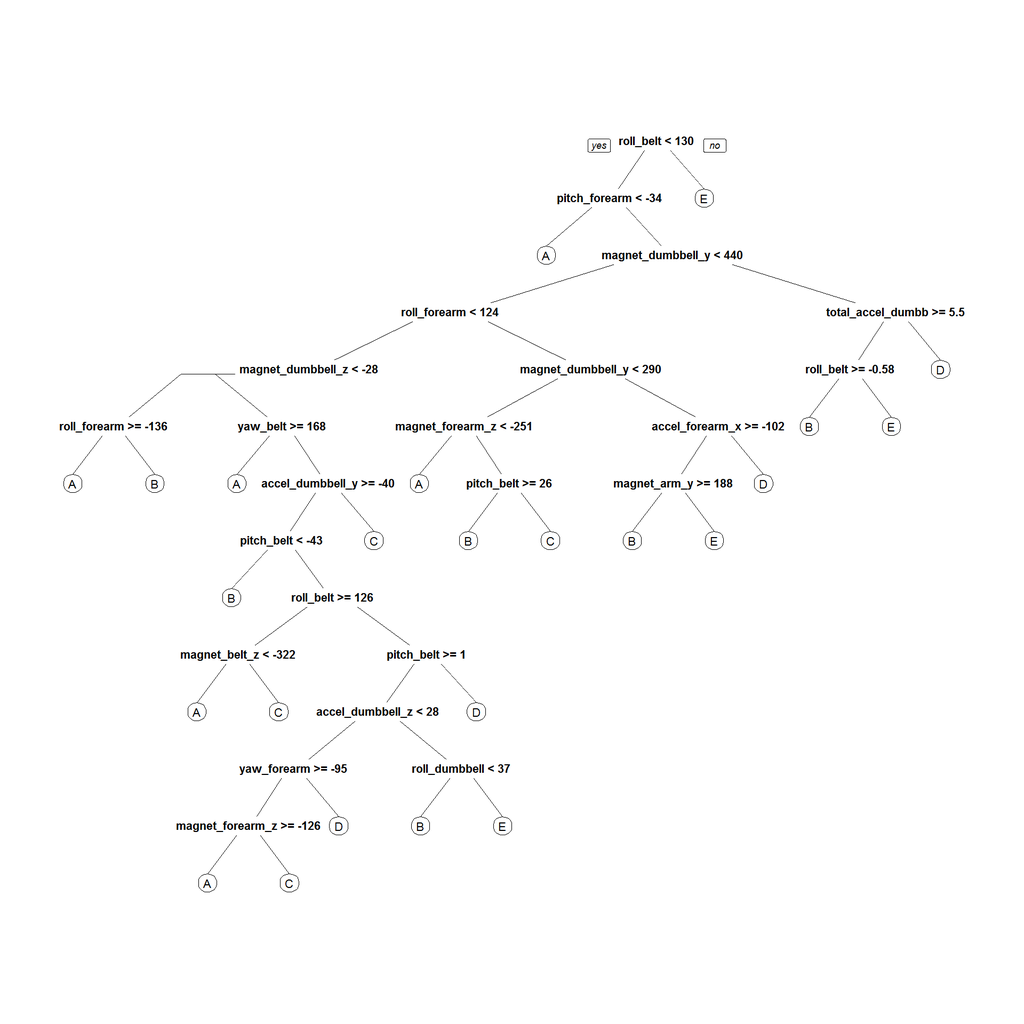

```r
tree <- rpart(classe ~ ., data = training, method = "class")
prp(tree)
```